# One-Way ANOVA

## Introduction: Analysis of Variance

- We have previously discussed testing the difference between two groups.
  - What about when there are three or more groups?
- We will use a method called **an**alysis **o**f **va**riance (ANOVA).
  - This method partitions the variance of the outcome into variance due to the groups and variance due to “other” factors.
- Fun fact: the two-sample *t*-test is a special case of ANOVA.
  - If you perform ANOVA when comparing two means, you will obtain the same results as the two-sample *t*-test.

## `R` Setup

```r
library(tidyverse)
library(ssstats)
apple_harvest <- read_csv("https://raw.githubusercontent.com/samanthaseals/STA4173Fa26/refs/heads/main/lectures/data/apple_harvest.csv")
baltimare_harbor <- read_csv("https://raw.githubusercontent.com/samanthaseals/STA4173Fa26/refs/heads/main/lectures/data/baltimare_harbor.csv")
boutique_gems <- read_csv("https://raw.githubusercontent.com/samanthaseals/STA4173Fa26/refs/heads/main/lectures/data/boutique_gems.csv")
klugetown_bazaar <- read_csv("https://raw.githubusercontent.com/samanthaseals/STA4173Fa26/refs/heads/main/lectures/data/klugetown_bazaar.csv")
ponyville_diner_tips <- read_csv("https://raw.githubusercontent.com/samanthaseals/STA4173Fa26/refs/heads/main/lectures/data/ponyville_diner_tips.csv")
wonderbolts_laptimes <- read_csv("https://raw.githubusercontent.com/samanthaseals/STA4173Fa26/refs/heads/main/lectures/data/wonderbolts_laptimes.csv")
```

## Analysis of Variance

- Consider comparing $k$ groups.

| Treatment (Level) | Observations | Total | Average |
| --- | --- | --- | --- |
| 1 | y<sub>11</sub> y<sub>12</sub> ⋯ y<sub>1n</sub> | y<sub>1·</sub> | ȳ<sub>1·</sub> |
| 2 | y<sub>21</sub> y<sub>22</sub> ⋯ y<sub>2n</sub> | y<sub>2·</sub> | ȳ<sub>2·</sub> |
| ⋮ | ⋮ | ⋮ | ⋮ |
| k | y<sub>k1</sub> y<sub>k2</sub> ⋯ y<sub>kn</sub> | y<sub>k·</sub> | ȳ<sub>k·</sub> |

## ANOVA Tables

- We will see our ANOVA results displayed in a table.
- Here is what we are working towards:

| Source | df | SS | MS | F | p-value |
| --- | --- | --- | --- | --- | --- |
| Treatment | df<sub>Trt</sub> | SS<sub>Trt</sub> | MS<sub>Trt</sub> | F<sub>Trt</sub> | *p*<sub>Trt</sub> |
| Residuals | df<sub>E</sub> | SS<sub>E</sub> | MS<sub>E</sub> |  |  |
| Total | df<sub>Tot</sub> | SS<sub>Tot</sub> |  |  |  |

## ANOVA: Sums of Squares

- We are *partitioning the total variability* into different components.
- The total sum of squares measures the overall variability in the data:

$$\text{SS}_{\text{Tot}} = \sum_{i=1}^k \sum_{j=1}^n (y_{ij} - \bar{y}_{..})^2$$

- and is partitioned into SS<sub>Trt</sub> and SS<sub>E</sub>:

$$\text{SS}_\text{Trt}=n \sum_{i=1}^k \left( \bar{y}_{i.}-\bar{y}_{..} \right)^2 \ \ \ \ \ \ \ \ \ \ \text{SS}_\text{E} = \sum_{i=1}^k \sum_{j=1}^n (y_{ij} - \bar{y}_{i.})^2$$

## ANOVA: Degrees of Freedom

- Next, we have the degrees of freedom. Each sum of square will have its own degrees of freedom.
- The total df:

$$\text{df}_{\text{Tot}} = n-1$$

- and is partitioned into df<sub>Trt</sub> and df<sub>E</sub>:

$$\text{df}_\text{Trt}=k - 1 \ \ \ \ \ \ \ \ \ \ \text{df}_\text{E} = n - k$$

## ANOVA: Mean Squares and Test Statistic

- To find the mean squares, we simply divide the sum of squares by the appropriate degrees of freedom,

$$\text{MS}_\text{Trt}=\frac{\text{SS}_{\text{Trt}}}{\text{df}_{\text{Trt}}} \ \ \ \ \ \ \ \ \ \ \text{MS}_\text{E}=\frac{\text{SS}_{\text{E}}}{\text{df}_{\text{E}}}$$

- Then, we can find our test statistic,

$$F_{\text{Trt}} = \frac{\text{MS}_{\text{Trt}}}{\text{MS}_{\text{E}}}$$

## ANOVA: Mean Squares and Test Statistic

- Note for the future: the MS and *F* can be generalized –

$$\text{MS}_\text{X}=\frac{\text{SS}_{\text{X}}}{\text{df}_{\text{X}}} \ \ \ \ \ \ \ \ \ \ F_{\text{X}} = \frac{\text{MS}_{\text{X}}}{\text{MS}_{\text{E}}}$$

- When constructing a test statistic in ANOVA, we always divide by MS<sub>E</sub>.

## ANOVA Tables

- Revisiting the ANOVA table,

| Source | df | SS | MS | F | p-value |
| --- | --- | --- | --- | --- | --- |
| Treatment | df<sub>Trt</sub> | SS<sub>Trt</sub> | MS<sub>Trt</sub> | F<sub>Trt</sub> | *p*<sub>Trt</sub> |
| Residuals | df<sub>E</sub> | SS<sub>E</sub> | MS<sub>E</sub> |  |  |
| Total | df<sub>Tot</sub> | SS<sub>Tot</sub> |  |  |  |

- Note the relationships:
  - SS<sub>Trt</sub> + SS<sub>E</sub> = SS<sub>Tot</sub>
  - df<sub>Trt</sub> + df<sub>E</sub> = df<sub>Tot</sub>

## Hypothesis Test for $\mu_1 = \mu_2 = ... = \mu_k$

- **Hypotheses**
  - $H_0: \mu_1 = \mu_2 = ... = \mu_k$
  - $H_1:$ at least one mean is different.
- **Test Statistic:**
  - $F_0 = \text{MS}_{\text{Trt}} / \text{MS}_{\text{E}}$

## Statistical Inference on $k$ Means (`R`)

- We will use the `anovas()` function from `library(ssstats)` to construct the ANOVA table.

```r
dataset_name |> anovas(outcome = continuous_variable,
                       grouping = grouping_variable,
                       alpha = alpha_level)
```

**1**

`outcome`: the continuous variable being compared across groups.

**2**

`grouping`: the categorical variable defining the groups (must have at least 2 levels).

**3**

`alpha`: the significance level; default is `0.05`.

## Example 1: Sweet Apple Acres

- Applejack has come to us: “Between the Red Delicious row, the Honeycrisp row, and that new Zap Apple row Granny Smith insisted on plantin’, I reckon one of ‘em oughta be doin’ better than the others. Can you tell me if they’re really any different, or am I just imaginin’ things?”

| row | bushels |
| --- | --- |
| Red Delicious Row | 42.2 |
| Red Delicious Row | 45.3 |
| Red Delicious Row | 42.1 |

- We will use the `apple_harvest` dataset to answer the following question:
  - Does apple harvest (in bushels) differ across the three orchard rows?

## Example 1

- What are the levels in our factor (`row`)?

```r
apple_harvest |> n_pct(row)
```

| row | n (pct) |
| --- | --- |
| Honeycrisp Row | 18 (33.3%) |
| Red Delicious Row | 18 (33.3%) |
| Zap Apple Row | 18 (33.3%) |

## Example 1

- What are the summary statistics by level of `row`?

```r
apple_harvest |> group_by(row) |> mean_median(bushels)
```

```
# A tibble: 3 × 4
  row               variable mean_sd    median_iqr
  <chr>             <chr>    <chr>      <chr>
1 Honeycrisp Row    bushels  41.6 (8.0) 41.0 (6.9)
2 Red Delicious Row bushels  40.6 (3.8) 42.0 (5.1)
3 Zap Apple Row     bushels  37.5 (4.4) 38.5 (5.1)
```

## Example 1

- Constructing the ANOVA table,

```r
apple_harvest |> anovas(outcome = bushels,
                        grouping = row)
```

```
One-way ANOVA

Source     df         SS       MS      F  p-value
────────────────────────────────────────────
row         2   160.9693  80.4846  2.468    0.095
Residuals  51  1663.4383  32.6164
────────────────────────────────────────────


Hypotheses (row):
H₀: All group means are equal (no effect of row)
H₁: At least one group mean differs (effect of row exists)
Test statistic: F(2, 51) = 2.468
p-value: 0.095
Conclusion: Fail to reject the null hypothesis (p = 0.095 ≥ α = 0.050)
```

## Example 1

- **Hypotheses**
  - $H_0: \mu_{\text{HC}} = \mu_{\text{RD}} = \mu_{\text{ZA}}$
  - $H_1:$ at least one mean is different.
- **Test Statistic and *p*-Value:**
  - $F_0 = 2.468$
  - $p = 0.095$
- **Rejection Region**
  - Reject $H_0$ if $p < \alpha$; $\alpha = 0.05$
- **Conclusion / Interpretation**
  - Fail to reject $H_0$. There is not sufficient evidence to suggest that the production of the rows are different.

## Example 2: Rarity’s Boutique

- Rarity flits between racks of fabric: “Darling, I need your professional opinion. Between my Canterlot Couture line, my everyday Ponyville Casual line, and my absolutely *dazzling* Gala Elegance line, I use wildly different amounts of gemstones. Is the difference really as dramatic as I think?”

| collection | gem_count |
| --- | --- |
| Canterlot Couture | 59 |
| Canterlot Couture | 57 |
| Canterlot Couture | 64 |

- We will use the `boutique_gems` dataset to answer the following question:
  - Does the number of gems used per dress differ across the three collections?

## Example 2

- What are the levels in our factor (`collection`)?

```r
boutique_gems |> n_pct(collection)
```

| collection | n (pct) |
| --- | --- |
| Canterlot Couture | 15 (33.3%) |
| Gala Elegance | 15 (33.3%) |
| Ponyville Casual | 15 (33.3%) |

## Example 2

- What are the summary statistics by level of `collection`?

```r
boutique_gems |> group_by(collection) |> mean_median(gem_count)
```

```
# A tibble: 3 × 4
  collection        variable  mean_sd     median_iqr
  <chr>             <chr>     <chr>       <chr>
1 Canterlot Couture gem_count 55.9 (8.4)  57.0 (8.0)
2 Gala Elegance     gem_count 124.3 (7.6) 124.0 (8.5)
3 Ponyville Casual  gem_count 87.9 (6.4)  87.0 (9.0)
```

## Example 2

- Constructing the ANOVA table,

```r
boutique_gems |> anovas(outcome = gem_count,
                       grouping = collection)
```

```
One-way ANOVA

Source      df          SS          MS        F  p-value
───────────────────────────────────────────────────
collection   2  35140.5778  17570.2889  311.110  < 0.001
Residuals   42   2372.0000     56.4762
───────────────────────────────────────────────────


Hypotheses (collection):
H₀: All group means are equal (no effect of collection)
H₁: At least one group mean differs (effect of collection exists)
Test statistic: F(2, 42) = 311.11
p-value: < 0.001
Conclusion: Reject the null hypothesis (p = < 0.001 < α = 0.050)
```

## Example 2

- **Hypotheses**
  - $H_0: \mu_{\text{CC}} = \mu_{\text{PC}} = \mu_{\text{GE}}$
  - $H_1:$ at least one mean is different.
- **Test Statistic and *p*-Value:**
  - $F_0 = 311.11$
  - $p < 0.001$
- **Rejection Region**
  - Reject $H_0$ if $p < \alpha$; $\alpha = 0.05$
- **Conclusion / Interpretation**
  - Reject $H_0$. There is sufficient evidence to suggest that the number of gems are different between the fashion lines.

## Example 3: Ponyville Diner

- Sunny Skies wipes down the counter after the lunch rush: “Feels like Caramel always walks away with better tips than me and Lyra put together. Before I start complainin’ to the manager, can you check if there’s actually a difference in how much we’re bringing in?”

| server | tip_bits |
| --- | --- |
| Sunny Skies | 4.08 |
| Sunny Skies | 6.12 |
| Sunny Skies | 0.12 |

- We will use the `ponyville_diner_tips` dataset to answer the following question:
  - Does tip amount differ across the three servers?

## Example 3

- What are the levels in our factor (`server`)?

```r
ponyville_diner_tips |> n_pct(server)
```

| server | n (pct) |
| --- | --- |
| Caramel | 22 (33.3%) |
| Lyra Heartstrings | 22 (33.3%) |
| Sunny Skies | 22 (33.3%) |

## Example 3

- What are the summary statistics by level of `server`?

```r
ponyville_diner_tips |> group_by(server) |> mean_median(tip_bits)
```

```
# A tibble: 3 × 4
  server            variable mean_sd   median_iqr
  <chr>             <chr>    <chr>     <chr>
1 Caramel           tip_bits 6.7 (4.4) 6.0 (5.9)
2 Lyra Heartstrings tip_bits 4.4 (4.7) 2.9 (2.9)
3 Sunny Skies       tip_bits 7.4 (8.9) 4.3 (8.5)
```

## Example 3

- Constructing the ANOVA table,

```r
ponyville_diner_tips |> anovas(outcome = tip_bits,
                       grouping = server)
```

```
One-way ANOVA

Source     df         SS       MS      F  p-value
────────────────────────────────────────────
server      2   109.2923  54.6461  1.356    0.265
Residuals  63  2539.3768  40.3076
────────────────────────────────────────────


Hypotheses (server):
H₀: All group means are equal (no effect of server)
H₁: At least one group mean differs (effect of server exists)
Test statistic: F(2, 63) = 1.356
p-value: 0.265
Conclusion: Fail to reject the null hypothesis (p = 0.265 ≥ α = 0.050)
```

## Example 3

- **Hypotheses**
  - $H_0: \mu_{\text{C}} = \mu_{\text{LH}} = \mu_{\text{SS}}$
  - $H_1:$ at least one mean is different.
- **Test Statistic and *p*-Value:**
  - $F_0 = 1.356$
  - $p = 0.265$
- **Rejection Region**
  - Reject $H_0$ if $p < \alpha$; $\alpha = 0.05$
- **Conclusion / Interpretation**
  - Fail to reject $H_0$. There is not sufficient evidence to suggest that the servers are earning different tips.

## ANOVA Assumptions

- We can represent ANOVA with the following model:

$$y_{ij} = \mu + \tau_i + \varepsilon_{ij}$$

- where:
  - $y_{ij}$ is the $j^{\text{th}}$ observation in the $i^{\text{th}}$ group,
  - $\mu$ is the overall (grand) mean,
  - $\tau_i$ is the treatment effect for group $i$, and
  - $\varepsilon_{ij}$ is the error term for the $j^{\text{th}}$ observation in the $i^{\text{th}}$ group.

## ANOVA Assumptions

- We assume that the error term follows a normal distribution with mean 0 and a constant variance, $\sigma^2$. i.e.,

$$\varepsilon_{ij} \overset{\text{iid}}{\sim} N(0, \sigma^2)$$

- Very important note: **the assumption is on the error term** ($\varepsilon_{ij}$) and NOT on the outcome ($y_{ij}$)!

## ANOVA Assumptions

- We will use the residual (the difference between the observed value and the predicted value) to assess assumptions:

$$e_{ij} = y_{ij} - \hat{y}_{ij}$$

- Note that in the case of one-way ANOVA, the predicted value of $y$ is the *group mean*.

## ANOVA Assumptions: Graphical Assessment

- **Normality**: quantile-quantile plot
  - Should have points close to the 45$^\circ$ line
  - We will focus on the “center” portion of the plot
- **Variance**: scatterplot of the residuals against the predicted values
  - Should be “equal spread” between the groups
  - No “pattern”

## Graphical Assessment of Assumptions (`R`)

- We will use the `anova_check()` function from `library(ssstats)` to assess normality.

```r
dataset_name |> anova_check(outcome = continuous_variable,
                       grouping = grouping_variable)
```

**1**

`outcome`: the continuous variable being compared across groups.

**2**

`grouping`: the categorical variable defining the groups (must have at least 2 levels).

- This will provide the the Q-Q plots and variance scatterplot necessary to assess the ANOVA assumptions.

## Example 1

- Checking the normality of our Sweet Apple Acres dataset,

```r
apple_harvest |> anova_check(outcome = bushels,
                             grouping = row)
```

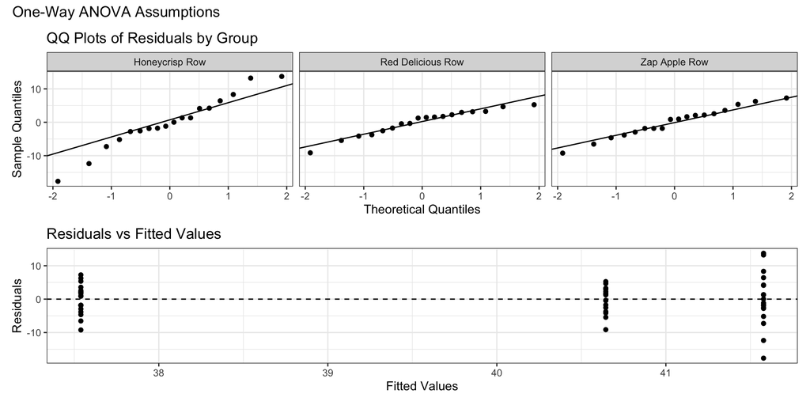

## Example 2

- Checking the normality of Rarity’s dataset,

```r
boutique_gems |> anova_check(outcome = gem_count,
                             grouping = collection)
```

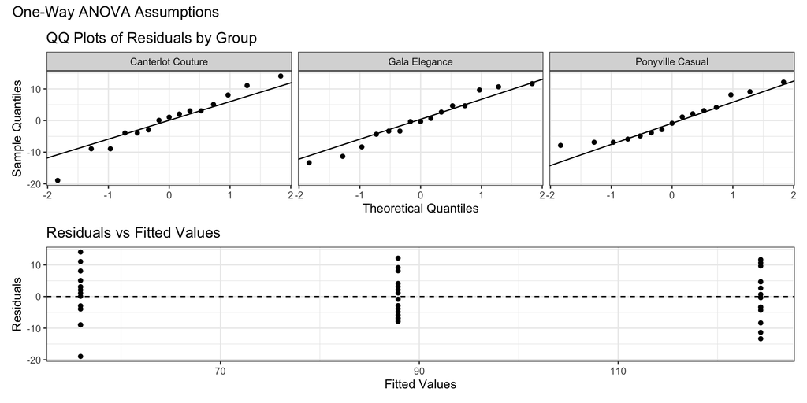

## Example 3

- Checking the normality of the Ponyville Diner dataset,

```r
ponyville_diner_tips |> anova_check(outcome = tip_bits,
                                    grouping = server)
```

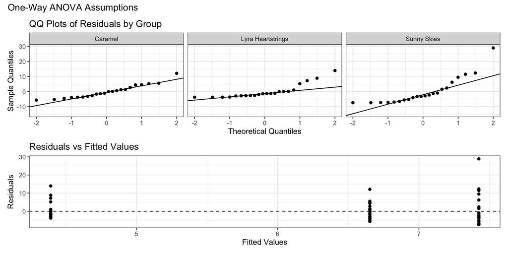

## Kruskal-Wallis

- If we break *either* ANOVA assumption, we should implement the nonparametric version, the Kruskal-Wallis.
  - The Kruskal-Wallis is an extension of the Wilcoxon rank sum (as ANOVA is an extension of the two-sample *t*-test).
- The Kruskal-Wallis test determines if $k$ independent samples come from populations with the same distribution.
- Note: we can transform the data to make the variance “behave”
  - Box-Cox, or power, transformation

## Hypothesis Test for $M_1 = M_2 = ... = M_k$

- **Hypotheses**
  - $H_0: M_1 = ... = M_k$
  - $H_1:$ at least one $M_i$ is different

## Hypothesis Testing: Kruskal-Wallis

- **Test Statistic**

$$\chi^2_0 = \frac{12}{n(n+1)} \sum_{i=1}^k \frac{R_i^2}{n_i} - 3(n+1) \sim \chi^2_{\text{df}}$$

- where
  - $R_i$ is the sum of the ranks for group $i$,
  - $n_i$ is the sample size for group $i$,
  - $n = \sum_{i=1}^k n_i$ = total sample size,
  - $k$ is the number of groups, and
  - $\text{df} = k-1$

## Statistical Inference on $k$ Medians (`R`)

- We will use the `kruskal_wallis()` function from `library(ssstats)` to perform the Kruskal-Wallis test.

```r
dataset_name |> kruskal_wallis(outcome = continuous_variable,
                               grouping = grouping_variable,
                               alpha = specified_alpha)
```

**1**

`outcome`: the continuous variable you want to compare across the groups.

**2**

`grouping`: the categorical variable that splits your data into groups.

**3**

`alpha`: the significance level; default is 0.05.

## Example 1

- Applying the Kruskal-Wallis to this example,

```r
apple_harvest |> kruskal_wallis(outcome = bushels,
                                grouping = row)
```

```
Kruskal-Wallis test

M[Honeycrisp Row] = 41 (n = 18)
M[Red Delicious Row] = 42 (n = 18)
M[Zap Apple Row] = 38.45 (n = 18)

Hypotheses:
H₀: All group distributions are equal (no effect of row)
H₁: At least one group distribution differs in location (effect of row exists)
Test statistic: H(2) = 5.953
p-value: 0.051
Conclusion: Fail to reject the null hypothesis (p = 0.051 ≥ α = 0.050)
```

## Example 3

- Applying the Kruskal-Wallis to this example,

```r
ponyville_diner_tips |> kruskal_wallis(outcome = tip_bits,
                       grouping = server)
```

```
Kruskal-Wallis test

M[Caramel] = 6.03 (n = 22)
M[Lyra Heartstrings] = 2.94 (n = 22)
M[Sunny Skies] = 4.305 (n = 22)

Hypotheses:
H₀: All group distributions are equal (no effect of server)
H₁: At least one group distribution differs in location (effect of server exists)
Test statistic: H(2) = 4.235
p-value: 0.120
Conclusion: Fail to reject the null hypothesis (p = 0.120 ≥ α = 0.050)
```

## Example 3

- **Hypotheses**
  - $H_0: M_{\text{C}} = M_{\text{LH}} = M_{\text{SS}}$
  - $H_1:$ at least one median is different.
- **Test Statistic and *p*-Value:**
  - $\chi^2_0 = 4.235$
  - $p = 0.120$
- **Rejection Region**
  - Reject $H_0$ if $p < \alpha$; $\alpha = 0.05$
- **Conclusion / Interpretation**
  - Fail to reject $H_0$. There is not sufficient evidence to suggest that the servers are earning different tips.

## Let’s Practice! Wonderbolts Academy

- Fleetfoot drops a stack of stopwatch printouts on the table: “Command wants to know if lap times actually differ across our four training squads: Thunderhead, Stormwing, Skybolt, and Downburst.”

| squad | lap_seconds |
| --- | --- |
| Thunderhead | 60.4 |
| Thunderhead | 59.6 |
| Thunderhead | 62.0 |

- We will use the `wonderbolts_laptimes` dataset to answer the following question:
  - Do lap times differ across the four training squads?

## Let’s Practice!: Klugetown Bazaar

- A weary trader waves you over between haggling matches: “Rustbolt, Glimmering, and Junker each swear their stall pulls in the best prices. I’ve got a season’s worth of sale records — do the three stalls actually sell for different amounts, or is everyone just talkin’ up their own wares?”

| stall | sale_price_bits |
| --- | --- |
| Rustbolt’s Relics | 21.25 |
| Rustbolt’s Relics | 18.93 |
| Rustbolt’s Relics | 26.79 |

- We will use the `klugetown_bazaar` dataset to answer the following question:
  - Does sale price differ across the three market stalls?

## Let’s Practice!: Baltimare Harbor

- The harbormaster spreads a stack of logbooks across the table: “Four dock crews unload every ship that comes through: Anchor, Tidewater, Saltmarsh, and Driftwood. Some of the sailors have been grumbling that one crew is dragging everyone’s schedule behind. Before I say anything to the crews, I want to know if unloading time actually differs across them.”

| crew | unload_minutes |
| --- | --- |
| Anchor Crew | 1.30 |
| Anchor Crew | 2.19 |
| Anchor Crew | 5.13 |

- We will use the `baltimare_harbor` dataset to answer the following question:
  - Does unloading time differ across the four dock crews?

## Wrap Up

- This lecture introduced one-way ANOVA.
  - One-way ANOVA examines the effect of a single factor.
  - (We will learn about multiple factors in the future!)
- One-way ANOVA only allows us to determine if there is an overall, or omnibus, effect.
  - It does *not* tell us about pairwise differences.
- In the future:
  - Posthoc testing
  - Two-way ANOVA
  - Profile plots